# Import libraries

```python
import tensorflow as tf
from tensorflow.keras.datasets import mnist
from tensorflow.keras.preprocessing import image
from tensorflow.keras.utils import to_categorical
import numpy as np
import os
from PIL import Image

# Libraries for showing random samples
from numpy import random
import matplotlib
import matplotlib.pyplot as plt

import keras
from keras import layers
```

# Import Data

```python
# Load the MNIST dataset
(x_train_raw, y_train_raw), (x_test_raw, y_test_raw) = mnist.load_data()

# Showing the dimension of the 4 sets
print(f"Dimension of the x_train set: {x_train_raw.shape} \n"
      f"Dimension of the y_train set: {y_train_raw.shape} \n"
      f"Dimension of the x_test set: {x_test_raw.shape} \n"
      f"Dimension of the y_test set: {y_test_raw.shape}")

# Normalize the input pixels from a range of [0,255] to [0,1]
x_train = x_train_raw/-255
x_test = x_test_raw/-255

input_shape = (28,28,1)
output_classes = 10
```

```
Dimension of the x_train set: (60000, 28, 28)
Dimension of the y_train set: (60000,)
Dimension of the x_test set: (10000, 28, 28)
Dimension of the y_test set: (10000,)
```

By running the code block above, it can be seen that

- 60,000 samples in the dataset are used in training.
- 10,000 samples are usedfor testing (approx 85/15 split)
- The input map has the size of 28x28

In the code block below, we can inspect the label column of the dataset to see how the desired labels are given.

```python
y_train_raw
```

```
array([5, 0, 4, ..., 5, 6, 8], dtype=uint8)
```

When run, the block returns an array of the training labels as the single integer output for each instances. However, I will later train a network to output a probability distribution of 10 different classes, each representing the digit from 0 to 9.

Therefore, I must use one-hot encoding to convert these single integer labels into $1\times10$ vectors. The code block below performs this operation and display the dimension of the training and testing labels

```python
# One hot encode the label
y_train = to_categorical(y_train_raw, num_classes=output_classes)
y_test = to_categorical(y_test_raw,num_classes=output_classes)

print(f"Dimension of the y_train set: {y_train.shape} \n"
      f"Dimension of the y_test set: {y_test.shape}")
```

```
Dimension of the y_train set: (60000, 10)
Dimension of the y_test set: (10000, 10)
```

The code block below is used for visualizing random handwritten digit samples in the dataset

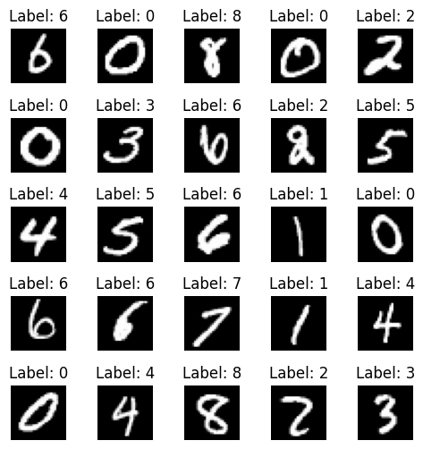

```python
num_samples = 25
rand = random.randint(60000,size = (num_samples))
x_samples = x_train[rand,:,:]
y_samples = np.argmax(y_train[rand,:],axis=1)

fig, axes = plt.subplots(5,5,figsize=(5,5))

for i in range(5):
  for j in range(5):
    ax = axes[i,j]
    ax.imshow(x_samples[i*5+j,:,:], cmap=matplotlib.cm.Greys)
    ax.axis("off")
    ax.set_title(f"Label: {y_samples[i*5+j]}")

plt.tight_layout()
plt.subplots_adjust(top=0.95)  # Adjust top to make room for title
plt.show()
```

# Helper Functions

```python
def plot_performance(history, learning_rate=None, batch_size=None):
  fig1, axes1 = plt.subplots(1,2,figsize = (10,5))

  # Accuracy of model training and validation vs training epoch
  acc_ax = axes1[0]
  acc_ax.plot(history.history['accuracy'])
  acc_ax.plot(history.history['val_accuracy'])

  if learning_rate and batch_size:
    acc_ax.set_title(f'Model accuracy \n lr = {learning_rate}, batch size = {batch_size}')
  else: acc_ax.set_title('Model accuracy')

  acc_ax.set_ylabel('Accuracy')
  acc_ax.set_xlabel('Epoch')
  acc_ax.legend(['Training', 'Validation'], loc='best')

  # Loss during model training and validation
  loss_ax = axes1[1]
  loss_ax.plot(history.history['loss'])
  loss_ax.plot(history.history['val_loss'])
  if learning_rate and batch_size:
    loss_ax.set_title(f'Model loss \n lr = {learning_rate}, batch size = {batch_size}')
  else: loss_ax.set_title('Model loss')
  loss_ax.set_ylabel('Loss')
  loss_ax.set_xlabel('Epoch')
  loss_ax.legend(['Training', 'Validation'], loc='best')
  plt.show()

  print(f"The model has a training accuracy of {history.history['accuracy'][-1]*100:.2f}%\n"
      f"The model has a validation accuracy of {history.history['val_accuracy'][-1]*100:.2f}%")
  return
```

# Construct the model

In this section, I shall build a simple 2D CNN borrowing the LeNet architecture, which was originally used for this dataset. This simplified network includes

- 2 convolutional layers, each followed by a max pooling layer
- 1 fully connected layer to output the final classification

```python
model = keras.Sequential([
    layers.Conv2D(32, kernel_size=(3, 3), activation="relu", input_shape = input_shape),
    layers.MaxPooling2D(pool_size=(2, 2)),
    layers.Conv2D(64, kernel_size=(3, 3), activation="relu"),
    layers.MaxPooling2D(pool_size=(2, 2)),
    layers.Flatten(),
    layers.Dense(output_classes, activation="softmax"),
])

intial_weights = model.get_weights()

model.summary()
```

```
d:\Minh Nguyen\TME_6015\.venv\Lib\site-packages\keras\src\layers\convolutional\base_conv.py:107: UserWarning: Do not pass an `input_shape`/`input_dim` argument to a layer. When using Sequential models, prefer using an `Input(shape)` object as the first layer in the model instead.
  super().__init__(activity_regularizer=activity_regularizer, **kwargs)
```

```
Model: "sequential"
```

```
┏━━━━━━━━━━━━━━━━━━━━━━━━━━━━━━━━━┳━━━━━━━━━━━━━━━━━━━━━━━━┳━━━━━━━━━━━━━━━┓
┃ Layer (type)                    ┃ Output Shape           ┃       Param # ┃
┡━━━━━━━━━━━━━━━━━━━━━━━━━━━━━━━━━╇━━━━━━━━━━━━━━━━━━━━━━━━╇━━━━━━━━━━━━━━━┩
│ conv2d (Conv2D)                 │ (None, 26, 26, 32)     │           320 │
├─────────────────────────────────┼────────────────────────┼───────────────┤
│ max_pooling2d (MaxPooling2D)    │ (None, 13, 13, 32)     │             0 │
├─────────────────────────────────┼────────────────────────┼───────────────┤
│ conv2d_1 (Conv2D)               │ (None, 11, 11, 64)     │        18,496 │
├─────────────────────────────────┼────────────────────────┼───────────────┤
│ max_pooling2d_1 (MaxPooling2D)  │ (None, 5, 5, 64)       │             0 │
├─────────────────────────────────┼────────────────────────┼───────────────┤
│ flatten (Flatten)               │ (None, 1600)           │             0 │
├─────────────────────────────────┼────────────────────────┼───────────────┤
│ dense (Dense)                   │ (None, 10)             │        16,010 │
└─────────────────────────────────┴────────────────────────┴───────────────┘
```

```
 Total params: 34,826 (136.04 KB)
```

```
 Trainable params: 34,826 (136.04 KB)
```

```
 Non-trainable params: 0 (0.00 B)
```

# Model Compilation and Training

This section compile the model crafted above with the Adam optimizer and a spcified learning rate of 0.0001. The model is then fitted using the MNIST training set

```python
batch_size = 128    # The number of samples seen before the model update the weights
epochs = 15         # Number of training episodes
lr = 0.0001          # Learning rate for the optimizer

optimizer1 = keras.optimizers.Adam(
    learning_rate = lr
)

model.compile(loss="categorical_crossentropy",
              optimizer=optimizer1,
              metrics=["accuracy"])

model.set_weights(intial_weights)

history = model.fit(x_train, y_train, batch_size=batch_size, epochs=epochs, validation_split=0.2)
```

```
375/375 ━━━━━━━━━━━━━━━━━━━━ 4s 8ms/step - accuracy: 0.5249 - loss: 1.7745 - val_accuracy: 0.9039 - val_loss: 0.3836
375/375 ━━━━━━━━━━━━━━━━━━━━ 3s 8ms/step - accuracy: 0.9032 - loss: 0.3547 - val_accuracy: 0.9367 - val_loss: 0.2298
375/375 ━━━━━━━━━━━━━━━━━━━━ 3s 8ms/step - accuracy: 0.9339 - loss: 0.2264 - val_accuracy: 0.9499 - val_loss: 0.1788
375/375 ━━━━━━━━━━━━━━━━━━━━ 3s 8ms/step - accuracy: 0.9480 - loss: 0.1812 - val_accuracy: 0.9597 - val_loss: 0.1458
375/375 ━━━━━━━━━━━━━━━━━━━━ 3s 8ms/step - accuracy: 0.9578 - loss: 0.1458 - val_accuracy: 0.9638 - val_loss: 0.1300
375/375 ━━━━━━━━━━━━━━━━━━━━ 3s 8ms/step - accuracy: 0.9634 - loss: 0.1277 - val_accuracy: 0.9675 - val_loss: 0.1150
375/375 ━━━━━━━━━━━━━━━━━━━━ 3s 9ms/step - accuracy: 0.9673 - loss: 0.1141 - val_accuracy: 0.9707 - val_loss: 0.1049
375/375 ━━━━━━━━━━━━━━━━━━━━ 3s 8ms/step - accuracy: 0.9716 - loss: 0.0980 - val_accuracy: 0.9734 - val_loss: 0.0964
375/375 ━━━━━━━━━━━━━━━━━━━━ 3s 9ms/step - accuracy: 0.9732 - loss: 0.0929 - val_accuracy: 0.9740 - val_loss: 0.0914
375/375 ━━━━━━━━━━━━━━━━━━━━ 4s 9ms/step - accuracy: 0.9738 - loss: 0.0875 - val_accuracy: 0.9753 - val_loss: 0.0857
375/375 ━━━━━━━━━━━━━━━━━━━━ 3s 9ms/step - accuracy: 0.9769 - loss: 0.0806 - val_accuracy: 0.9758 - val_loss: 0.0807
375/375 ━━━━━━━━━━━━━━━━━━━━ 3s 9ms/step - accuracy: 0.9767 - loss: 0.0770 - val_accuracy: 0.9772 - val_loss: 0.0774
375/375 ━━━━━━━━━━━━━━━━━━━━ 4s 10ms/step - accuracy: 0.9782 - loss: 0.0728 - val_accuracy: 0.9783 - val_loss: 0.0739
375/375 ━━━━━━━━━━━━━━━━━━━━ 4s 10ms/step - accuracy: 0.9807 - loss: 0.0634 - val_accuracy: 0.9788 - val_loss: 0.0701
375/375 ━━━━━━━━━━━━━━━━━━━━ 3s 9ms/step - accuracy: 0.9792 - loss: 0.0673 - val_accuracy: 0.9799 - val_loss: 0.0698
```

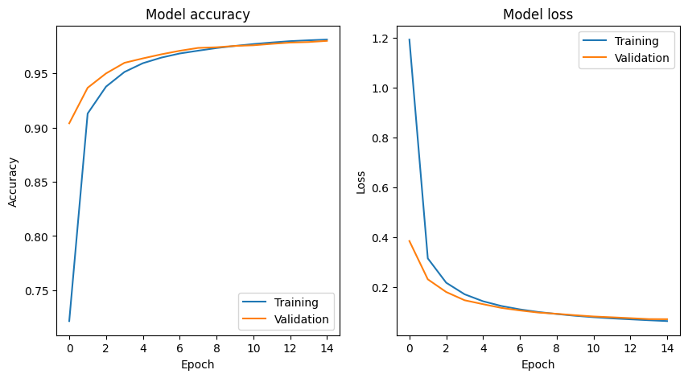

```
The model has a training accuracy of 98.11%
The model has a validation accuracy of 97.99%
```

```python
plot_performance(history)
```

# Model Retraining

In this section, I am increasing the number of epochs to 150 so that the model can continue learning until it starts to overfit (validation loss starts increasing)

```python
batch_size = 128    # The number of samples seen before the model update the weights
epochs = 150        # Number of training episodes
lr = 0.0001         # Learning rate for the optimizer


optimizer = keras.optimizers.Adam(
    learning_rate = lr
)
model.set_weights(intial_weights)
model.compile(loss="categorical_crossentropy",
              optimizer=optimizer1,
              metrics=["accuracy"])

history_1 = model.fit(x_train, y_train, batch_size=batch_size, epochs=epochs, validation_split=0.2)
```

```
375/375 ━━━━━━━━━━━━━━━━━━━━ 4s 10ms/step - accuracy: 0.5193 - loss: 1.6737 - val_accuracy: 0.8965 - val_loss: 0.3758
375/375 ━━━━━━━━━━━━━━━━━━━━ 4s 10ms/step - accuracy: 0.8965 - loss: 0.3640 - val_accuracy: 0.9254 - val_loss: 0.2590
375/375 ━━━━━━━━━━━━━━━━━━━━ 4s 10ms/step - accuracy: 0.9254 - loss: 0.2551 - val_accuracy: 0.9433 - val_loss: 0.1978
375/375 ━━━━━━━━━━━━━━━━━━━━ 4s 10ms/step - accuracy: 0.9422 - loss: 0.1951 - val_accuracy: 0.9535 - val_loss: 0.1627
375/375 ━━━━━━━━━━━━━━━━━━━━ 4s 10ms/step - accuracy: 0.9524 - loss: 0.1638 - val_accuracy: 0.9622 - val_loss: 0.1373
375/375 ━━━━━━━━━━━━━━━━━━━━ 3s 9ms/step - accuracy: 0.9612 - loss: 0.1341 - val_accuracy: 0.9664 - val_loss: 0.1194
375/375 ━━━━━━━━━━━━━━━━━━━━ 3s 9ms/step - accuracy: 0.9650 - loss: 0.1207 - val_accuracy: 0.9697 - val_loss: 0.1079
375/375 ━━━━━━━━━━━━━━━━━━━━ 3s 9ms/step - accuracy: 0.9692 - loss: 0.1062 - val_accuracy: 0.9714 - val_loss: 0.0985
375/375 ━━━━━━━━━━━━━━━━━━━━ 4s 10ms/step - accuracy: 0.9716 - loss: 0.0928 - val_accuracy: 0.9741 - val_loss: 0.0905
375/375 ━━━━━━━━━━━━━━━━━━━━ 4s 10ms/step - accuracy: 0.9744 - loss: 0.0858 - val_accuracy: 0.9747 - val_loss: 0.0841
375/375 ━━━━━━━━━━━━━━━━━━━━ 4s 11ms/step - accuracy: 0.9767 - loss: 0.0788 - val_accuracy: 0.9770 - val_loss: 0.0776
375/375 ━━━━━━━━━━━━━━━━━━━━ 4s 10ms/step - accuracy: 0.9780 - loss: 0.0732 - val_accuracy: 0.9780 - val_loss: 0.0772
375/375 ━━━━━━━━━━━━━━━━━━━━ 3s 8ms/step - accuracy: 0.9784 - loss: 0.0709 - val_accuracy: 0.9794 - val_loss: 0.0734
375/375 ━━━━━━━━━━━━━━━━━━━━ 4s 10ms/step - accuracy: 0.9809 - loss: 0.0657 - val_accuracy: 0.9800 - val_loss: 0.0691
375/375 ━━━━━━━━━━━━━━━━━━━━ 3s 9ms/step - accuracy: 0.9819 - loss: 0.0622 - val_accuracy: 0.9796 - val_loss: 0.0687
375/375 ━━━━━━━━━━━━━━━━━━━━ 4s 10ms/step - accuracy: 0.9815 - loss: 0.0610 - val_accuracy: 0.9812 - val_loss: 0.0672
375/375 ━━━━━━━━━━━━━━━━━━━━ 4s 10ms/step - accuracy: 0.9824 - loss: 0.0571 - val_accuracy: 0.9803 - val_loss: 0.0643
375/375 ━━━━━━━━━━━━━━━━━━━━ 3s 9ms/step - accuracy: 0.9847 - loss: 0.0526 - val_accuracy: 0.9814 - val_loss: 0.0633
375/375 ━━━━━━━━━━━━━━━━━━━━ 3s 9ms/step - accuracy: 0.9832 - loss: 0.0538 - val_accuracy: 0.9824 - val_loss: 0.0605
375/375 ━━━━━━━━━━━━━━━━━━━━ 3s 9ms/step - accuracy: 0.9847 - loss: 0.0520 - val_accuracy: 0.9828 - val_loss: 0.0592
375/375 ━━━━━━━━━━━━━━━━━━━━ 3s 8ms/step - accuracy: 0.9853 - loss: 0.0494 - val_accuracy: 0.9824 - val_loss: 0.0589
375/375 ━━━━━━━━━━━━━━━━━━━━ 3s 9ms/step - accuracy: 0.9859 - loss: 0.0480 - val_accuracy: 0.9829 - val_loss: 0.0597
375/375 ━━━━━━━━━━━━━━━━━━━━ 4s 10ms/step - accuracy: 0.9867 - loss: 0.0451 - val_accuracy: 0.9824 - val_loss: 0.0592
375/375 ━━━━━━━━━━━━━━━━━━━━ 4s 9ms/step - accuracy: 0.9885 - loss: 0.0408 - val_accuracy: 0.9833 - val_loss: 0.0559
375/375 ━━━━━━━━━━━━━━━━━━━━ 3s 9ms/step - accuracy: 0.9876 - loss: 0.0414 - val_accuracy: 0.9830 - val_loss: 0.0553
375/375 ━━━━━━━━━━━━━━━━━━━━ 3s 9ms/step - accuracy: 0.9881 - loss: 0.0417 - val_accuracy: 0.9835 - val_loss: 0.0572
375/375 ━━━━━━━━━━━━━━━━━━━━ 4s 10ms/step - accuracy: 0.9880 - loss: 0.0401 - val_accuracy: 0.9830 - val_loss: 0.0557
375/375 ━━━━━━━━━━━━━━━━━━━━ 4s 10ms/step - accuracy: 0.9889 - loss: 0.0386 - val_accuracy: 0.9833 - val_loss: 0.0575
375/375 ━━━━━━━━━━━━━━━━━━━━ 4s 11ms/step - accuracy: 0.9882 - loss: 0.0386 - val_accuracy: 0.9842 - val_loss: 0.0525
375/375 ━━━━━━━━━━━━━━━━━━━━ 4s 10ms/step - accuracy: 0.9895 - loss: 0.0364 - val_accuracy: 0.9843 - val_loss: 0.0523
375/375 ━━━━━━━━━━━━━━━━━━━━ 4s 11ms/step - accuracy: 0.9893 - loss: 0.0356 - val_accuracy: 0.9839 - val_loss: 0.0540
375/375 ━━━━━━━━━━━━━━━━━━━━ 4s 9ms/step - accuracy: 0.9889 - loss: 0.0364 - val_accuracy: 0.9848 - val_loss: 0.0520
375/375 ━━━━━━━━━━━━━━━━━━━━ 4s 9ms/step - accuracy: 0.9903 - loss: 0.0343 - val_accuracy: 0.9848 - val_loss: 0.0531
375/375 ━━━━━━━━━━━━━━━━━━━━ 3s 9ms/step - accuracy: 0.9909 - loss: 0.0312 - val_accuracy: 0.9842 - val_loss: 0.0539
375/375 ━━━━━━━━━━━━━━━━━━━━ 4s 10ms/step - accuracy: 0.9901 - loss: 0.0319 - val_accuracy: 0.9841 - val_loss: 0.0528
375/375 ━━━━━━━━━━━━━━━━━━━━ 4s 10ms/step - accuracy: 0.9909 - loss: 0.0305 - val_accuracy: 0.9847 - val_loss: 0.0516
375/375 ━━━━━━━━━━━━━━━━━━━━ 4s 10ms/step - accuracy: 0.9911 - loss: 0.0310 - val_accuracy: 0.9846 - val_loss: 0.0517
375/375 ━━━━━━━━━━━━━━━━━━━━ 4s 10ms/step - accuracy: 0.9908 - loss: 0.0314 - val_accuracy: 0.9846 - val_loss: 0.0519
375/375 ━━━━━━━━━━━━━━━━━━━━ 3s 8ms/step - accuracy: 0.9908 - loss: 0.0313 - val_accuracy: 0.9843 - val_loss: 0.0525
375/375 ━━━━━━━━━━━━━━━━━━━━ 4s 10ms/step - accuracy: 0.9914 - loss: 0.0286 - val_accuracy: 0.9856 - val_loss: 0.0490
```

[output cut: 95 more lines]

```
375/375 ━━━━━━━━━━━━━━━━━━━━ 4s 10ms/step - accuracy: 0.9997 - loss: 0.0025 - val_accuracy: 0.9852 - val_loss: 0.0683
375/375 ━━━━━━━━━━━━━━━━━━━━ 4s 10ms/step - accuracy: 0.9997 - loss: 0.0027 - val_accuracy: 0.9861 - val_loss: 0.0668
375/375 ━━━━━━━━━━━━━━━━━━━━ 3s 9ms/step - accuracy: 0.9994 - loss: 0.0029 - val_accuracy: 0.9849 - val_loss: 0.0717
375/375 ━━━━━━━━━━━━━━━━━━━━ 3s 9ms/step - accuracy: 0.9992 - loss: 0.0032 - val_accuracy: 0.9859 - val_loss: 0.0668
375/375 ━━━━━━━━━━━━━━━━━━━━ 3s 8ms/step - accuracy: 0.9994 - loss: 0.0030 - val_accuracy: 0.9867 - val_loss: 0.0645
375/375 ━━━━━━━━━━━━━━━━━━━━ 3s 8ms/step - accuracy: 0.9996 - loss: 0.0024 - val_accuracy: 0.9847 - val_loss: 0.0706
375/375 ━━━━━━━━━━━━━━━━━━━━ 3s 9ms/step - accuracy: 0.9997 - loss: 0.0024 - val_accuracy: 0.9862 - val_loss: 0.0655
375/375 ━━━━━━━━━━━━━━━━━━━━ 4s 10ms/step - accuracy: 0.9998 - loss: 0.0018 - val_accuracy: 0.9860 - val_loss: 0.0681
375/375 ━━━━━━━━━━━━━━━━━━━━ 4s 10ms/step - accuracy: 0.9991 - loss: 0.0038 - val_accuracy: 0.9865 - val_loss: 0.0661
375/375 ━━━━━━━━━━━━━━━━━━━━ 3s 9ms/step - accuracy: 0.9999 - loss: 0.0017 - val_accuracy: 0.9848 - val_loss: 0.0737
375/375 ━━━━━━━━━━━━━━━━━━━━ 3s 8ms/step - accuracy: 0.9997 - loss: 0.0022 - val_accuracy: 0.9861 - val_loss: 0.0665
375/375 ━━━━━━━━━━━━━━━━━━━━ 3s 9ms/step - accuracy: 0.9997 - loss: 0.0019 - val_accuracy: 0.9858 - val_loss: 0.0671
375/375 ━━━━━━━━━━━━━━━━━━━━ 4s 10ms/step - accuracy: 0.9999 - loss: 0.0018 - val_accuracy: 0.9862 - val_loss: 0.0670
375/375 ━━━━━━━━━━━━━━━━━━━━ 3s 9ms/step - accuracy: 1.0000 - loss: 0.0015 - val_accuracy: 0.9866 - val_loss: 0.0701
375/375 ━━━━━━━━━━━━━━━━━━━━ 4s 10ms/step - accuracy: 0.9997 - loss: 0.0017 - val_accuracy: 0.9856 - val_loss: 0.0733
```

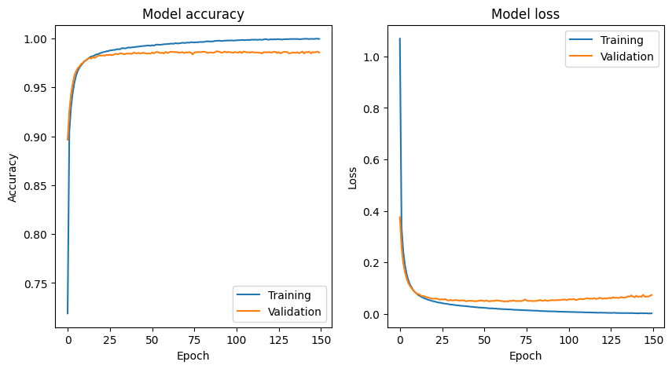

```
The model has a training accuracy of 99.96%
The model has a validation accuracy of 98.56%
```

```python
plot_performance(history_1)
```

One can see that the model has started to overfit around 50 epochs. This number is fixed moving forward for the hyperparameter experiment

# Model Hyperparameter Experiment

## Learning Rate Experiment

In the code block below, the learning rate are varied between [0.001, 0.0005, and 0.0001] to evaluate the model training. The number of epochs is fixed at 50 and the batch size at 128

```python
history_all = []

batch_size = 128
epochs = 50
lr = [0.001, 0.0005, 0.0001]

for i in range(len(lr)):
    # Reset the weights of the model to start training from the same initial weights
    model.set_weights(intial_weights)

    # Adjust the optimizer with the corresponding learning rate
    optimizer = keras.optimizers.Adam(learning_rate = lr[i])

    model.compile(loss="categorical_crossentropy",
                optimizer=optimizer,
                metrics=["accuracy"])

    print(f"=== Model training with lr = {lr[i]}, batch size = {batch_size} ===")
    history = model.fit(x_train, y_train, batch_size=batch_size, epochs=epochs, validation_split=0.2)

    # Append a dictionary of the training parameters and training history
    history_all.append({
        'learning_rate': lr[i],
        'batch_size': batch_size,
        'history': history
    })
```

```
=== Model training with lr = 0.001, batch size = 128 ===
375/375 ━━━━━━━━━━━━━━━━━━━━ 4s 9ms/step - accuracy: 0.7973 - loss: 0.7009 - val_accuracy: 0.9710 - val_loss: 0.0970
375/375 ━━━━━━━━━━━━━━━━━━━━ 3s 9ms/step - accuracy: 0.9748 - loss: 0.0854 - val_accuracy: 0.9779 - val_loss: 0.0706
375/375 ━━━━━━━━━━━━━━━━━━━━ 4s 9ms/step - accuracy: 0.9810 - loss: 0.0608 - val_accuracy: 0.9838 - val_loss: 0.0557
375/375 ━━━━━━━━━━━━━━━━━━━━ 3s 8ms/step - accuracy: 0.9856 - loss: 0.0454 - val_accuracy: 0.9838 - val_loss: 0.0548
375/375 ━━━━━━━━━━━━━━━━━━━━ 3s 8ms/step - accuracy: 0.9885 - loss: 0.0372 - val_accuracy: 0.9872 - val_loss: 0.0442
375/375 ━━━━━━━━━━━━━━━━━━━━ 4s 9ms/step - accuracy: 0.9904 - loss: 0.0321 - val_accuracy: 0.9852 - val_loss: 0.0503
375/375 ━━━━━━━━━━━━━━━━━━━━ 3s 9ms/step - accuracy: 0.9906 - loss: 0.0288 - val_accuracy: 0.9869 - val_loss: 0.0424
375/375 ━━━━━━━━━━━━━━━━━━━━ 3s 9ms/step - accuracy: 0.9924 - loss: 0.0247 - val_accuracy: 0.9870 - val_loss: 0.0438
375/375 ━━━━━━━━━━━━━━━━━━━━ 3s 8ms/step - accuracy: 0.9936 - loss: 0.0214 - val_accuracy: 0.9869 - val_loss: 0.0489
375/375 ━━━━━━━━━━━━━━━━━━━━ 3s 9ms/step - accuracy: 0.9941 - loss: 0.0199 - val_accuracy: 0.9873 - val_loss: 0.0436
375/375 ━━━━━━━━━━━━━━━━━━━━ 4s 9ms/step - accuracy: 0.9958 - loss: 0.0143 - val_accuracy: 0.9878 - val_loss: 0.0427
375/375 ━━━━━━━━━━━━━━━━━━━━ 3s 9ms/step - accuracy: 0.9955 - loss: 0.0142 - val_accuracy: 0.9863 - val_loss: 0.0476
375/375 ━━━━━━━━━━━━━━━━━━━━ 3s 9ms/step - accuracy: 0.9957 - loss: 0.0118 - val_accuracy: 0.9888 - val_loss: 0.0465
375/375 ━━━━━━━━━━━━━━━━━━━━ 3s 9ms/step - accuracy: 0.9968 - loss: 0.0105 - val_accuracy: 0.9865 - val_loss: 0.0503
375/375 ━━━━━━━━━━━━━━━━━━━━ 3s 9ms/step - accuracy: 0.9973 - loss: 0.0091 - val_accuracy: 0.9868 - val_loss: 0.0514
375/375 ━━━━━━━━━━━━━━━━━━━━ 3s 9ms/step - accuracy: 0.9976 - loss: 0.0080 - val_accuracy: 0.9887 - val_loss: 0.0473
375/375 ━━━━━━━━━━━━━━━━━━━━ 4s 10ms/step - accuracy: 0.9980 - loss: 0.0067 - val_accuracy: 0.9885 - val_loss: 0.0496
375/375 ━━━━━━━━━━━━━━━━━━━━ 3s 8ms/step - accuracy: 0.9976 - loss: 0.0068 - val_accuracy: 0.9892 - val_loss: 0.0512
375/375 ━━━━━━━━━━━━━━━━━━━━ 3s 9ms/step - accuracy: 0.9987 - loss: 0.0049 - val_accuracy: 0.9888 - val_loss: 0.0535
375/375 ━━━━━━━━━━━━━━━━━━━━ 3s 8ms/step - accuracy: 0.9987 - loss: 0.0043 - val_accuracy: 0.9886 - val_loss: 0.0499
375/375 ━━━━━━━━━━━━━━━━━━━━ 3s 8ms/step - accuracy: 0.9991 - loss: 0.0032 - val_accuracy: 0.9887 - val_loss: 0.0518
375/375 ━━━━━━━━━━━━━━━━━━━━ 4s 9ms/step - accuracy: 0.9983 - loss: 0.0046 - val_accuracy: 0.9884 - val_loss: 0.0548
375/375 ━━━━━━━━━━━━━━━━━━━━ 3s 9ms/step - accuracy: 0.9994 - loss: 0.0028 - val_accuracy: 0.9883 - val_loss: 0.0610
375/375 ━━━━━━━━━━━━━━━━━━━━ 3s 8ms/step - accuracy: 0.9981 - loss: 0.0058 - val_accuracy: 0.9888 - val_loss: 0.0589
375/375 ━━━━━━━━━━━━━━━━━━━━ 4s 9ms/step - accuracy: 0.9998 - loss: 0.0014 - val_accuracy: 0.9892 - val_loss: 0.0568
375/375 ━━━━━━━━━━━━━━━━━━━━ 3s 9ms/step - accuracy: 0.9994 - loss: 0.0018 - val_accuracy: 0.9902 - val_loss: 0.0559
375/375 ━━━━━━━━━━━━━━━━━━━━ 4s 10ms/step - accuracy: 0.9978 - loss: 0.0060 - val_accuracy: 0.9890 - val_loss: 0.0553
375/375 ━━━━━━━━━━━━━━━━━━━━ 4s 10ms/step - accuracy: 0.9992 - loss: 0.0033 - val_accuracy: 0.9903 - val_loss: 0.0548
375/375 ━━━━━━━━━━━━━━━━━━━━ 3s 9ms/step - accuracy: 0.9998 - loss: 9.7028e-04 - val_accuracy: 0.9889 - val_loss: 0.0585
375/375 ━━━━━━━━━━━━━━━━━━━━ 4s 9ms/step - accuracy: 0.9993 - loss: 0.0022 - val_accuracy: 0.9888 - val_loss: 0.0612
375/375 ━━━━━━━━━━━━━━━━━━━━ 4s 10ms/step - accuracy: 0.9995 - loss: 0.0016 - val_accuracy: 0.9901 - val_loss: 0.0557
375/375 ━━━━━━━━━━━━━━━━━━━━ 3s 9ms/step - accuracy: 0.9996 - loss: 0.0012 - val_accuracy: 0.9887 - val_loss: 0.0657
375/375 ━━━━━━━━━━━━━━━━━━━━ 4s 10ms/step - accuracy: 0.9981 - loss: 0.0046 - val_accuracy: 0.9901 - val_loss: 0.0580
375/375 ━━━━━━━━━━━━━━━━━━━━ 3s 9ms/step - accuracy: 0.9998 - loss: 0.0010 - val_accuracy: 0.9897 - val_loss: 0.0640
375/375 ━━━━━━━━━━━━━━━━━━━━ 3s 9ms/step - accuracy: 0.9992 - loss: 0.0018 - val_accuracy: 0.9902 - val_loss: 0.0638
375/375 ━━━━━━━━━━━━━━━━━━━━ 3s 9ms/step - accuracy: 0.9988 - loss: 0.0035 - val_accuracy: 0.9867 - val_loss: 0.0769
375/375 ━━━━━━━━━━━━━━━━━━━━ 3s 9ms/step - accuracy: 0.9998 - loss: 0.0010 - val_accuracy: 0.9888 - val_loss: 0.0720
375/375 ━━━━━━━━━━━━━━━━━━━━ 3s 9ms/step - accuracy: 0.9998 - loss: 9.4008e-04 - val_accuracy: 0.9883 - val_loss: 0.0692
375/375 ━━━━━━━━━━━━━━━━━━━━ 4s 10ms/step - accuracy: 0.9989 - loss: 0.0029 - val_accuracy: 0.9890 - val_loss: 0.0736
```

[output cut: 98 more lines]

```
375/375 ━━━━━━━━━━━━━━━━━━━━ 3s 8ms/step - accuracy: 0.9898 - loss: 0.0346 - val_accuracy: 0.9846 - val_loss: 0.0542
375/375 ━━━━━━━━━━━━━━━━━━━━ 3s 8ms/step - accuracy: 0.9892 - loss: 0.0329 - val_accuracy: 0.9846 - val_loss: 0.0533
375/375 ━━━━━━━━━━━━━━━━━━━━ 3s 9ms/step - accuracy: 0.9902 - loss: 0.0325 - val_accuracy: 0.9851 - val_loss: 0.0518
375/375 ━━━━━━━━━━━━━━━━━━━━ 3s 9ms/step - accuracy: 0.9919 - loss: 0.0291 - val_accuracy: 0.9852 - val_loss: 0.0510
375/375 ━━━━━━━━━━━━━━━━━━━━ 3s 8ms/step - accuracy: 0.9911 - loss: 0.0319 - val_accuracy: 0.9850 - val_loss: 0.0530
375/375 ━━━━━━━━━━━━━━━━━━━━ 3s 8ms/step - accuracy: 0.9913 - loss: 0.0291 - val_accuracy: 0.9852 - val_loss: 0.0505
375/375 ━━━━━━━━━━━━━━━━━━━━ 3s 9ms/step - accuracy: 0.9916 - loss: 0.0296 - val_accuracy: 0.9852 - val_loss: 0.0521
375/375 ━━━━━━━━━━━━━━━━━━━━ 4s 10ms/step - accuracy: 0.9924 - loss: 0.0277 - val_accuracy: 0.9850 - val_loss: 0.0522
375/375 ━━━━━━━━━━━━━━━━━━━━ 4s 10ms/step - accuracy: 0.9918 - loss: 0.0279 - val_accuracy: 0.9854 - val_loss: 0.0523
375/375 ━━━━━━━━━━━━━━━━━━━━ 4s 10ms/step - accuracy: 0.9918 - loss: 0.0276 - val_accuracy: 0.9843 - val_loss: 0.0562
375/375 ━━━━━━━━━━━━━━━━━━━━ 3s 9ms/step - accuracy: 0.9916 - loss: 0.0277 - val_accuracy: 0.9864 - val_loss: 0.0504
375/375 ━━━━━━━━━━━━━━━━━━━━ 3s 9ms/step - accuracy: 0.9928 - loss: 0.0260 - val_accuracy: 0.9852 - val_loss: 0.0519
375/375 ━━━━━━━━━━━━━━━━━━━━ 4s 9ms/step - accuracy: 0.9929 - loss: 0.0260 - val_accuracy: 0.9859 - val_loss: 0.0492
375/375 ━━━━━━━━━━━━━━━━━━━━ 3s 9ms/step - accuracy: 0.9921 - loss: 0.0268 - val_accuracy: 0.9859 - val_loss: 0.0503
375/375 ━━━━━━━━━━━━━━━━━━━━ 3s 8ms/step - accuracy: 0.9928 - loss: 0.0241 - val_accuracy: 0.9864 - val_loss: 0.0485
```

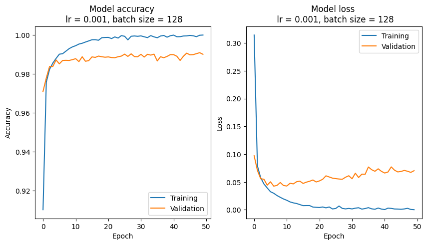

```
The model has a training accuracy of 100.00%
The model has a validation accuracy of 99.01%
```

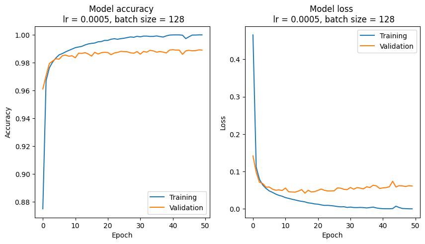

```
The model has a training accuracy of 100.00%
The model has a validation accuracy of 98.91%
```

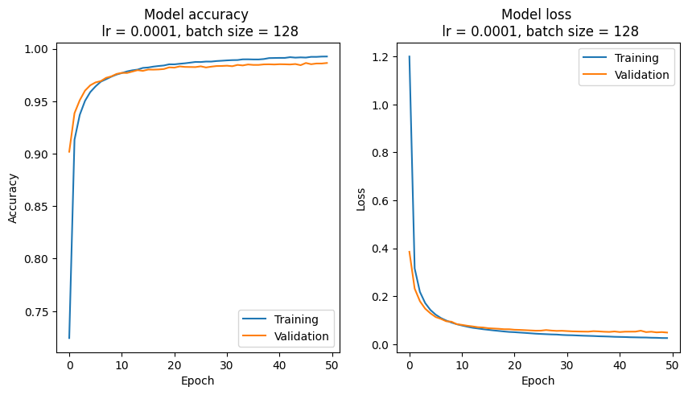

```
The model has a training accuracy of 99.26%
The model has a validation accuracy of 98.64%
```

```python
for i in range(len(lr)):
    learning_rate_eps = history_all[i]['learning_rate']
    batch_size_eps = history_all[i]['batch_size']

    plot_performance(history_all[i]['history'],learning_rate_eps,batch_size_eps)
```

## Batch size experiment

```python
history_all = []

batch_size = [32, 64, 128]
epochs = 15
lr = 0.0001

for i in range(len(batch_size)):
    # Reset the weights of the model to start training from the same initial weights
    model.set_weights(intial_weights)

    # Adjust the optimizer with the corresponding learning rate
    optimizer = keras.optimizers.Adam(learning_rate = lr)

    model.compile(loss="categorical_crossentropy",
                optimizer=optimizer,
                metrics=["accuracy"])

    print(f"=== Model training with lr = {lr}, batch size = {batch_size[i]} ===")
    history = model.fit(x_train, y_train, batch_size=batch_size[i], epochs=epochs, validation_split=0.2)

    # Append a dictionary of the training parameters and training history
    history_all.append({
        'learning_rate': lr,
        'batch_size': batch_size[i],
        'history': history
    })
```

```
=== Model training with lr = 0.0001, batch size = 32 ===
1500/1500 ━━━━━━━━━━━━━━━━━━━━ 6s 3ms/step - accuracy: 0.7027 - loss: 1.1380 - val_accuracy: 0.9423 - val_loss: 0.2003
1500/1500 ━━━━━━━━━━━━━━━━━━━━ 5s 3ms/step - accuracy: 0.9467 - loss: 0.1861 - val_accuracy: 0.9624 - val_loss: 0.1327
1500/1500 ━━━━━━━━━━━━━━━━━━━━ 5s 3ms/step - accuracy: 0.9621 - loss: 0.1294 - val_accuracy: 0.9708 - val_loss: 0.1027
1500/1500 ━━━━━━━━━━━━━━━━━━━━ 5s 3ms/step - accuracy: 0.9719 - loss: 0.0962 - val_accuracy: 0.9712 - val_loss: 0.0945
1500/1500 ━━━━━━━━━━━━━━━━━━━━ 5s 3ms/step - accuracy: 0.9754 - loss: 0.0811 - val_accuracy: 0.9763 - val_loss: 0.0810
1500/1500 ━━━━━━━━━━━━━━━━━━━━ 5s 3ms/step - accuracy: 0.9787 - loss: 0.0732 - val_accuracy: 0.9748 - val_loss: 0.0816
1500/1500 ━━━━━━━━━━━━━━━━━━━━ 5s 3ms/step - accuracy: 0.9787 - loss: 0.0709 - val_accuracy: 0.9789 - val_loss: 0.0711
1500/1500 ━━━━━━━━━━━━━━━━━━━━ 5s 3ms/step - accuracy: 0.9802 - loss: 0.0626 - val_accuracy: 0.9808 - val_loss: 0.0645
1500/1500 ━━━━━━━━━━━━━━━━━━━━ 5s 3ms/step - accuracy: 0.9827 - loss: 0.0549 - val_accuracy: 0.9821 - val_loss: 0.0602
1500/1500 ━━━━━━━━━━━━━━━━━━━━ 5s 4ms/step - accuracy: 0.9846 - loss: 0.0531 - val_accuracy: 0.9822 - val_loss: 0.0589
1500/1500 ━━━━━━━━━━━━━━━━━━━━ 5s 4ms/step - accuracy: 0.9855 - loss: 0.0477 - val_accuracy: 0.9829 - val_loss: 0.0607
1500/1500 ━━━━━━━━━━━━━━━━━━━━ 5s 3ms/step - accuracy: 0.9878 - loss: 0.0428 - val_accuracy: 0.9832 - val_loss: 0.0550
1500/1500 ━━━━━━━━━━━━━━━━━━━━ 5s 4ms/step - accuracy: 0.9868 - loss: 0.0431 - val_accuracy: 0.9842 - val_loss: 0.0547
1500/1500 ━━━━━━━━━━━━━━━━━━━━ 5s 3ms/step - accuracy: 0.9870 - loss: 0.0425 - val_accuracy: 0.9830 - val_loss: 0.0553
1500/1500 ━━━━━━━━━━━━━━━━━━━━ 5s 3ms/step - accuracy: 0.9891 - loss: 0.0384 - val_accuracy: 0.9841 - val_loss: 0.0539
=== Model training with lr = 0.0001, batch size = 64 ===
750/750 ━━━━━━━━━━━━━━━━━━━━ 5s 6ms/step - accuracy: 0.6377 - loss: 1.4280 - val_accuracy: 0.9302 - val_loss: 0.2603
750/750 ━━━━━━━━━━━━━━━━━━━━ 4s 6ms/step - accuracy: 0.9286 - loss: 0.2541 - val_accuracy: 0.9524 - val_loss: 0.1712
750/750 ━━━━━━━━━━━━━━━━━━━━ 4s 6ms/step - accuracy: 0.9520 - loss: 0.1653 - val_accuracy: 0.9632 - val_loss: 0.1324
750/750 ━━━━━━━━━━━━━━━━━━━━ 4s 5ms/step - accuracy: 0.9637 - loss: 0.1301 - val_accuracy: 0.9682 - val_loss: 0.1120
750/750 ━━━━━━━━━━━━━━━━━━━━ 4s 5ms/step - accuracy: 0.9680 - loss: 0.1096 - val_accuracy: 0.9716 - val_loss: 0.0990
750/750 ━━━━━━━━━━━━━━━━━━━━ 4s 6ms/step - accuracy: 0.9731 - loss: 0.0886 - val_accuracy: 0.9737 - val_loss: 0.0890
750/750 ━━━━━━━━━━━━━━━━━━━━ 4s 6ms/step - accuracy: 0.9744 - loss: 0.0834 - val_accuracy: 0.9753 - val_loss: 0.0826
750/750 ━━━━━━━━━━━━━━━━━━━━ 4s 5ms/step - accuracy: 0.9780 - loss: 0.0749 - val_accuracy: 0.9780 - val_loss: 0.0758
750/750 ━━━━━━━━━━━━━━━━━━━━ 4s 6ms/step - accuracy: 0.9793 - loss: 0.0708 - val_accuracy: 0.9779 - val_loss: 0.0734
750/750 ━━━━━━━━━━━━━━━━━━━━ 4s 6ms/step - accuracy: 0.9814 - loss: 0.0628 - val_accuracy: 0.9793 - val_loss: 0.0709
750/750 ━━━━━━━━━━━━━━━━━━━━ 4s 5ms/step - accuracy: 0.9826 - loss: 0.0604 - val_accuracy: 0.9804 - val_loss: 0.0665
750/750 ━━━━━━━━━━━━━━━━━━━━ 4s 5ms/step - accuracy: 0.9816 - loss: 0.0586 - val_accuracy: 0.9796 - val_loss: 0.0663
750/750 ━━━━━━━━━━━━━━━━━━━━ 4s 5ms/step - accuracy: 0.9845 - loss: 0.0533 - val_accuracy: 0.9814 - val_loss: 0.0623
750/750 ━━━━━━━━━━━━━━━━━━━━ 4s 6ms/step - accuracy: 0.9861 - loss: 0.0483 - val_accuracy: 0.9808 - val_loss: 0.0626
750/750 ━━━━━━━━━━━━━━━━━━━━ 4s 5ms/step - accuracy: 0.9853 - loss: 0.0508 - val_accuracy: 0.9835 - val_loss: 0.0581
=== Model training with lr = 0.0001, batch size = 128 ===
375/375 ━━━━━━━━━━━━━━━━━━━━ 4s 9ms/step - accuracy: 0.5350 - loss: 1.7776 - val_accuracy: 0.9017 - val_loss: 0.3880
375/375 ━━━━━━━━━━━━━━━━━━━━ 3s 9ms/step - accuracy: 0.9001 - loss: 0.3614 - val_accuracy: 0.9380 - val_loss: 0.2318
375/375 ━━━━━━━━━━━━━━━━━━━━ 3s 9ms/step - accuracy: 0.9337 - loss: 0.2314 - val_accuracy: 0.9507 - val_loss: 0.1780
375/375 ━━━━━━━━━━━━━━━━━━━━ 4s 10ms/step - accuracy: 0.9483 - loss: 0.1799 - val_accuracy: 0.9595 - val_loss: 0.1501
375/375 ━━━━━━━━━━━━━━━━━━━━ 4s 9ms/step - accuracy: 0.9587 - loss: 0.1455 - val_accuracy: 0.9647 - val_loss: 0.1291
375/375 ━━━━━━━━━━━━━━━━━━━━ 3s 9ms/step - accuracy: 0.9626 - loss: 0.1283 - val_accuracy: 0.9685 - val_loss: 0.1137
375/375 ━━━━━━━━━━━━━━━━━━━━ 3s 8ms/step - accuracy: 0.9660 - loss: 0.1118 - val_accuracy: 0.9693 - val_loss: 0.1080
375/375 ━━━━━━━━━━━━━━━━━━━━ 3s 9ms/step - accuracy: 0.9687 - loss: 0.1040 - val_accuracy: 0.9732 - val_loss: 0.0936
375/375 ━━━━━━━━━━━━━━━━━━━━ 4s 10ms/step - accuracy: 0.9730 - loss: 0.0917 - val_accuracy: 0.9737 - val_loss: 0.0894
375/375 ━━━━━━━━━━━━━━━━━━━━ 4s 9ms/step - accuracy: 0.9745 - loss: 0.0870 - val_accuracy: 0.9749 - val_loss: 0.0842
375/375 ━━━━━━━━━━━━━━━━━━━━ 4s 9ms/step - accuracy: 0.9760 - loss: 0.0803 - val_accuracy: 0.9773 - val_loss: 0.0787
375/375 ━━━━━━━━━━━━━━━━━━━━ 3s 9ms/step - accuracy: 0.9777 - loss: 0.0755 - val_accuracy: 0.9770 - val_loss: 0.0759
375/375 ━━━━━━━━━━━━━━━━━━━━ 3s 8ms/step - accuracy: 0.9783 - loss: 0.0717 - val_accuracy: 0.9778 - val_loss: 0.0747
375/375 ━━━━━━━━━━━━━━━━━━━━ 3s 9ms/step - accuracy: 0.9812 - loss: 0.0647 - val_accuracy: 0.9787 - val_loss: 0.0708
375/375 ━━━━━━━━━━━━━━━━━━━━ 3s 8ms/step - accuracy: 0.9827 - loss: 0.0591 - val_accuracy: 0.9793 - val_loss: 0.0682
```

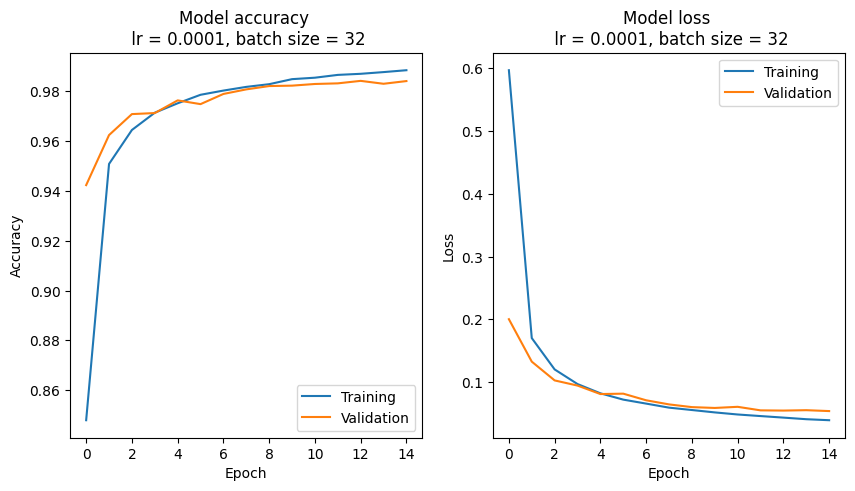

```
The model has a training accuracy of 98.84%
The model has a validation accuracy of 98.41%
```

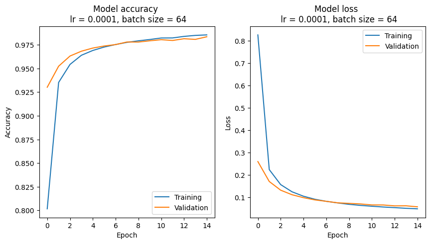

```
The model has a training accuracy of 98.55%
The model has a validation accuracy of 98.35%
```

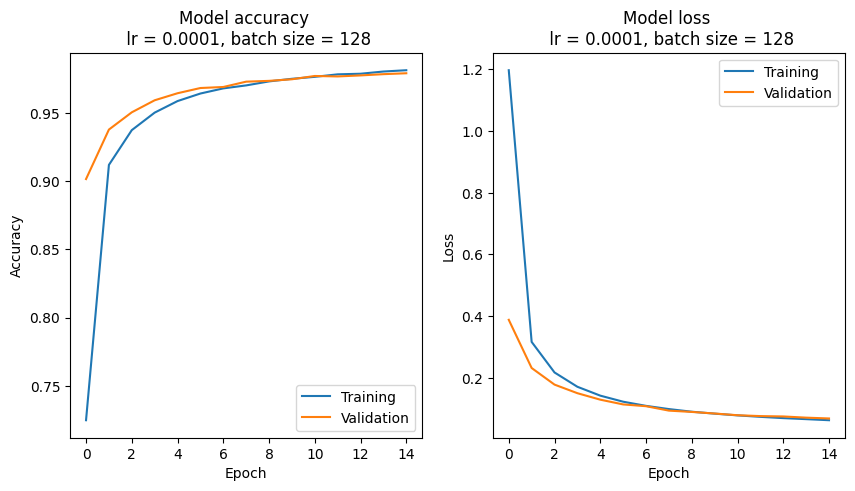

```
The model has a training accuracy of 98.16%
The model has a validation accuracy of 97.93%
```

```python
for i in range(len(batch_size)):
    learning_rate_eps = history_all[i]['learning_rate']
    batch_size_eps = history_all[i]['batch_size']

    plot_performance(history_all[i]['history'],learning_rate_eps,batch_size_eps)
```

## Model Architecture Experiment

In this experiment, all hyperparameters are fixed

- batch size = 128
- learning rate = 0.0001
- epochs = 50

- The first convolution layer will have 32 filters
- The subsequent convolution layer(s) will have 64 filters each
- The filters all have size 3x3 and the convolution operations all have a stride of 1

```python
batch_size = 128
lr = 0.0001
epochs = 50
```

```python
tf.keras.backend.clear_session(
    free_memory=True
)

optimizer = keras.optimizers.Adam(
    learning_rate = lr
)

model_2Conv = keras.Sequential([
    layers.Conv2D(32, kernel_size=(3, 3), activation="relu", input_shape = input_shape),
    layers.MaxPooling2D(pool_size=(2, 2)),
    layers.Conv2D(64, kernel_size=(3, 3), activation="relu", input_shape = input_shape),
    layers.MaxPooling2D(pool_size=(2, 2)),
    layers.Flatten(),
    layers.Dense(output_classes, activation="softmax"),
])

model_2Conv.summary()

model_2Conv.compile(loss="categorical_crossentropy",
              optimizer=optimizer,
              metrics=["accuracy"])

history_2Conv = model_2Conv.fit(x_train, y_train, batch_size=batch_size, epochs=epochs, validation_split=0.2)
```

```
WARNING:tensorflow:From d:\Minh Nguyen\TME_6015\.venv\Lib\site-packages\keras\src\backend\common\global_state.py:82: The name tf.reset_default_graph is deprecated. Please use tf.compat.v1.reset_default_graph instead.
```

```
Model: "sequential"
```

```
┏━━━━━━━━━━━━━━━━━━━━━━━━━━━━━━━━━┳━━━━━━━━━━━━━━━━━━━━━━━━┳━━━━━━━━━━━━━━━┓
┃ Layer (type)                    ┃ Output Shape           ┃       Param # ┃
┡━━━━━━━━━━━━━━━━━━━━━━━━━━━━━━━━━╇━━━━━━━━━━━━━━━━━━━━━━━━╇━━━━━━━━━━━━━━━┩
│ conv2d (Conv2D)                 │ (None, 26, 26, 32)     │           320 │
├─────────────────────────────────┼────────────────────────┼───────────────┤
│ max_pooling2d (MaxPooling2D)    │ (None, 13, 13, 32)     │             0 │
├─────────────────────────────────┼────────────────────────┼───────────────┤
│ conv2d_1 (Conv2D)               │ (None, 11, 11, 64)     │        18,496 │
├─────────────────────────────────┼────────────────────────┼───────────────┤
│ max_pooling2d_1 (MaxPooling2D)  │ (None, 5, 5, 64)       │             0 │
├─────────────────────────────────┼────────────────────────┼───────────────┤
│ flatten (Flatten)               │ (None, 1600)           │             0 │
├─────────────────────────────────┼────────────────────────┼───────────────┤
│ dense (Dense)                   │ (None, 10)             │        16,010 │
└─────────────────────────────────┴────────────────────────┴───────────────┘
```

```
 Total params: 34,826 (136.04 KB)
```

```
 Trainable params: 34,826 (136.04 KB)
```

```
 Non-trainable params: 0 (0.00 B)
```

```
375/375 ━━━━━━━━━━━━━━━━━━━━ 4s 10ms/step - accuracy: 0.5148 - loss: 1.7556 - val_accuracy: 0.9038 - val_loss: 0.3689
375/375 ━━━━━━━━━━━━━━━━━━━━ 3s 9ms/step - accuracy: 0.9064 - loss: 0.3429 - val_accuracy: 0.9377 - val_loss: 0.2278
375/375 ━━━━━━━━━━━━━━━━━━━━ 4s 9ms/step - accuracy: 0.9331 - loss: 0.2317 - val_accuracy: 0.9491 - val_loss: 0.1804
375/375 ━━━━━━━━━━━━━━━━━━━━ 3s 9ms/step - accuracy: 0.9467 - loss: 0.1829 - val_accuracy: 0.9597 - val_loss: 0.1486
375/375 ━━━━━━━━━━━━━━━━━━━━ 3s 8ms/step - accuracy: 0.9560 - loss: 0.1499 - val_accuracy: 0.9658 - val_loss: 0.1285
375/375 ━━━━━━━━━━━━━━━━━━━━ 3s 9ms/step - accuracy: 0.9611 - loss: 0.1324 - val_accuracy: 0.9676 - val_loss: 0.1159
375/375 ━━━━━━━━━━━━━━━━━━━━ 3s 9ms/step - accuracy: 0.9674 - loss: 0.1136 - val_accuracy: 0.9710 - val_loss: 0.1055
375/375 ━━━━━━━━━━━━━━━━━━━━ 3s 8ms/step - accuracy: 0.9685 - loss: 0.1054 - val_accuracy: 0.9718 - val_loss: 0.0991
375/375 ━━━━━━━━━━━━━━━━━━━━ 3s 8ms/step - accuracy: 0.9720 - loss: 0.0928 - val_accuracy: 0.9743 - val_loss: 0.0924
375/375 ━━━━━━━━━━━━━━━━━━━━ 4s 9ms/step - accuracy: 0.9737 - loss: 0.0882 - val_accuracy: 0.9759 - val_loss: 0.0870
375/375 ━━━━━━━━━━━━━━━━━━━━ 3s 9ms/step - accuracy: 0.9743 - loss: 0.0858 - val_accuracy: 0.9765 - val_loss: 0.0840
375/375 ━━━━━━━━━━━━━━━━━━━━ 3s 8ms/step - accuracy: 0.9774 - loss: 0.0772 - val_accuracy: 0.9765 - val_loss: 0.0815
375/375 ━━━━━━━━━━━━━━━━━━━━ 3s 9ms/step - accuracy: 0.9780 - loss: 0.0737 - val_accuracy: 0.9777 - val_loss: 0.0784
375/375 ━━━━━━━━━━━━━━━━━━━━ 3s 9ms/step - accuracy: 0.9799 - loss: 0.0665 - val_accuracy: 0.9773 - val_loss: 0.0765
375/375 ━━━━━━━━━━━━━━━━━━━━ 4s 11ms/step - accuracy: 0.9792 - loss: 0.0666 - val_accuracy: 0.9791 - val_loss: 0.0747
375/375 ━━━━━━━━━━━━━━━━━━━━ 4s 10ms/step - accuracy: 0.9815 - loss: 0.0621 - val_accuracy: 0.9792 - val_loss: 0.0713
375/375 ━━━━━━━━━━━━━━━━━━━━ 3s 9ms/step - accuracy: 0.9818 - loss: 0.0600 - val_accuracy: 0.9805 - val_loss: 0.0680
375/375 ━━━━━━━━━━━━━━━━━━━━ 3s 9ms/step - accuracy: 0.9826 - loss: 0.0584 - val_accuracy: 0.9803 - val_loss: 0.0674
375/375 ━━━━━━━━━━━━━━━━━━━━ 3s 9ms/step - accuracy: 0.9829 - loss: 0.0555 - val_accuracy: 0.9802 - val_loss: 0.0656
375/375 ━━━━━━━━━━━━━━━━━━━━ 3s 9ms/step - accuracy: 0.9825 - loss: 0.0569 - val_accuracy: 0.9788 - val_loss: 0.0687
375/375 ━━━━━━━━━━━━━━━━━━━━ 3s 8ms/step - accuracy: 0.9843 - loss: 0.0520 - val_accuracy: 0.9813 - val_loss: 0.0643
375/375 ━━━━━━━━━━━━━━━━━━━━ 3s 9ms/step - accuracy: 0.9832 - loss: 0.0543 - val_accuracy: 0.9808 - val_loss: 0.0623
375/375 ━━━━━━━━━━━━━━━━━━━━ 3s 9ms/step - accuracy: 0.9852 - loss: 0.0488 - val_accuracy: 0.9827 - val_loss: 0.0610
375/375 ━━━━━━━━━━━━━━━━━━━━ 3s 9ms/step - accuracy: 0.9860 - loss: 0.0478 - val_accuracy: 0.9828 - val_loss: 0.0601
375/375 ━━━━━━━━━━━━━━━━━━━━ 4s 10ms/step - accuracy: 0.9856 - loss: 0.0459 - val_accuracy: 0.9818 - val_loss: 0.0596
375/375 ━━━━━━━━━━━━━━━━━━━━ 3s 9ms/step - accuracy: 0.9867 - loss: 0.0464 - val_accuracy: 0.9825 - val_loss: 0.0580
375/375 ━━━━━━━━━━━━━━━━━━━━ 3s 9ms/step - accuracy: 0.9875 - loss: 0.0440 - val_accuracy: 0.9822 - val_loss: 0.0585
375/375 ━━━━━━━━━━━━━━━━━━━━ 3s 9ms/step - accuracy: 0.9876 - loss: 0.0425 - val_accuracy: 0.9812 - val_loss: 0.0587
375/375 ━━━━━━━━━━━━━━━━━━━━ 3s 9ms/step - accuracy: 0.9876 - loss: 0.0427 - val_accuracy: 0.9822 - val_loss: 0.0586
375/375 ━━━━━━━━━━━━━━━━━━━━ 3s 9ms/step - accuracy: 0.9876 - loss: 0.0401 - val_accuracy: 0.9834 - val_loss: 0.0567
375/375 ━━━━━━━━━━━━━━━━━━━━ 4s 10ms/step - accuracy: 0.9879 - loss: 0.0410 - val_accuracy: 0.9833 - val_loss: 0.0557
375/375 ━━━━━━━━━━━━━━━━━━━━ 4s 9ms/step - accuracy: 0.9884 - loss: 0.0386 - val_accuracy: 0.9823 - val_loss: 0.0563
375/375 ━━━━━━━━━━━━━━━━━━━━ 4s 9ms/step - accuracy: 0.9880 - loss: 0.0404 - val_accuracy: 0.9835 - val_loss: 0.0555
375/375 ━━━━━━━━━━━━━━━━━━━━ 4s 10ms/step - accuracy: 0.9891 - loss: 0.0379 - val_accuracy: 0.9834 - val_loss: 0.0557
375/375 ━━━━━━━━━━━━━━━━━━━━ 4s 9ms/step - accuracy: 0.9892 - loss: 0.0370 - val_accuracy: 0.9832 - val_loss: 0.0560
375/375 ━━━━━━━━━━━━━━━━━━━━ 3s 9ms/step - accuracy: 0.9895 - loss: 0.0353 - val_accuracy: 0.9827 - val_loss: 0.0546
375/375 ━━━━━━━━━━━━━━━━━━━━ 3s 8ms/step - accuracy: 0.9895 - loss: 0.0370 - val_accuracy: 0.9833 - val_loss: 0.0559
375/375 ━━━━━━━━━━━━━━━━━━━━ 3s 9ms/step - accuracy: 0.9903 - loss: 0.0339 - val_accuracy: 0.9837 - val_loss: 0.0541
375/375 ━━━━━━━━━━━━━━━━━━━━ 4s 10ms/step - accuracy: 0.9891 - loss: 0.0339 - val_accuracy: 0.9841 - val_loss: 0.0525
375/375 ━━━━━━━━━━━━━━━━━━━━ 4s 9ms/step - accuracy: 0.9909 - loss: 0.0329 - val_accuracy: 0.9837 - val_loss: 0.0541
375/375 ━━━━━━━━━━━━━━━━━━━━ 4s 9ms/step - accuracy: 0.9901 - loss: 0.0328 - val_accuracy: 0.9827 - val_loss: 0.0537
375/375 ━━━━━━━━━━━━━━━━━━━━ 3s 9ms/step - accuracy: 0.9910 - loss: 0.0314 - val_accuracy: 0.9824 - val_loss: 0.0554
375/375 ━━━━━━━━━━━━━━━━━━━━ 3s 9ms/step - accuracy: 0.9901 - loss: 0.0321 - val_accuracy: 0.9843 - val_loss: 0.0529
375/375 ━━━━━━━━━━━━━━━━━━━━ 4s 9ms/step - accuracy: 0.9912 - loss: 0.0299 - val_accuracy: 0.9835 - val_loss: 0.0524
375/375 ━━━━━━━━━━━━━━━━━━━━ 3s 9ms/step - accuracy: 0.9920 - loss: 0.0293 - val_accuracy: 0.9846 - val_loss: 0.0516
375/375 ━━━━━━━━━━━━━━━━━━━━ 4s 10ms/step - accuracy: 0.9912 - loss: 0.0297 - val_accuracy: 0.9843 - val_loss: 0.0515
375/375 ━━━━━━━━━━━━━━━━━━━━ 3s 9ms/step - accuracy: 0.9912 - loss: 0.0308 - val_accuracy: 0.9844 - val_loss: 0.0546
375/375 ━━━━━━━━━━━━━━━━━━━━ 4s 10ms/step - accuracy: 0.9912 - loss: 0.0304 - val_accuracy: 0.9846 - val_loss: 0.0534
375/375 ━━━━━━━━━━━━━━━━━━━━ 3s 9ms/step - accuracy: 0.9920 - loss: 0.0293 - val_accuracy: 0.9833 - val_loss: 0.0538
375/375 ━━━━━━━━━━━━━━━━━━━━ 4s 10ms/step - accuracy: 0.9913 - loss: 0.0274 - val_accuracy: 0.9834 - val_loss: 0.0530
```

```python
tf.keras.backend.clear_session(
    free_memory=True
)

optimizer = keras.optimizers.Adam(
    learning_rate = lr
)

model_3Conv = keras.Sequential([
    layers.Conv2D(32, kernel_size=(3, 3), activation="relu", input_shape = input_shape),
    layers.MaxPooling2D(pool_size=(2, 2)),
    layers.Conv2D(64, kernel_size=(3, 3), activation="relu"),
    layers.MaxPooling2D(pool_size=(2, 2)),
    layers.Conv2D(64, kernel_size=(3, 3), activation="relu"),
    layers.MaxPooling2D(pool_size=(2, 2)),
    layers.Flatten(),
    layers.Dense(output_classes, activation="softmax"),
])

model_3Conv.summary()

model_3Conv.compile(loss="categorical_crossentropy",
              optimizer=optimizer,
              metrics=["accuracy"])

history_3Conv = model_3Conv.fit(x_train, y_train, batch_size=batch_size, epochs=epochs, validation_split=0.2)
```

```
Model: "sequential"
```

```
┏━━━━━━━━━━━━━━━━━━━━━━━━━━━━━━━━━┳━━━━━━━━━━━━━━━━━━━━━━━━┳━━━━━━━━━━━━━━━┓
┃ Layer (type)                    ┃ Output Shape           ┃       Param # ┃
┡━━━━━━━━━━━━━━━━━━━━━━━━━━━━━━━━━╇━━━━━━━━━━━━━━━━━━━━━━━━╇━━━━━━━━━━━━━━━┩
│ conv2d (Conv2D)                 │ (None, 26, 26, 32)     │           320 │
├─────────────────────────────────┼────────────────────────┼───────────────┤
│ max_pooling2d (MaxPooling2D)    │ (None, 13, 13, 32)     │             0 │
├─────────────────────────────────┼────────────────────────┼───────────────┤
│ conv2d_1 (Conv2D)               │ (None, 11, 11, 64)     │        18,496 │
├─────────────────────────────────┼────────────────────────┼───────────────┤
│ max_pooling2d_1 (MaxPooling2D)  │ (None, 5, 5, 64)       │             0 │
├─────────────────────────────────┼────────────────────────┼───────────────┤
│ conv2d_2 (Conv2D)               │ (None, 3, 3, 64)       │        36,928 │
├─────────────────────────────────┼────────────────────────┼───────────────┤
│ max_pooling2d_2 (MaxPooling2D)  │ (None, 1, 1, 64)       │             0 │
├─────────────────────────────────┼────────────────────────┼───────────────┤
│ flatten (Flatten)               │ (None, 64)             │             0 │
├─────────────────────────────────┼────────────────────────┼───────────────┤
│ dense (Dense)                   │ (None, 10)             │           650 │
└─────────────────────────────────┴────────────────────────┴───────────────┘
```

```
 Total params: 56,394 (220.29 KB)
```

```
 Trainable params: 56,394 (220.29 KB)
```

```
 Non-trainable params: 0 (0.00 B)
```

```
375/375 ━━━━━━━━━━━━━━━━━━━━ 5s 11ms/step - accuracy: 0.4821 - loss: 1.8706 - val_accuracy: 0.8868 - val_loss: 0.4399
375/375 ━━━━━━━━━━━━━━━━━━━━ 4s 11ms/step - accuracy: 0.8932 - loss: 0.4008 - val_accuracy: 0.9278 - val_loss: 0.2520
375/375 ━━━━━━━━━━━━━━━━━━━━ 4s 11ms/step - accuracy: 0.9277 - loss: 0.2533 - val_accuracy: 0.9422 - val_loss: 0.1931
375/375 ━━━━━━━━━━━━━━━━━━━━ 4s 11ms/step - accuracy: 0.9444 - loss: 0.1924 - val_accuracy: 0.9510 - val_loss: 0.1658
375/375 ━━━━━━━━━━━━━━━━━━━━ 4s 10ms/step - accuracy: 0.9494 - loss: 0.1699 - val_accuracy: 0.9568 - val_loss: 0.1484
375/375 ━━━━━━━━━━━━━━━━━━━━ 4s 10ms/step - accuracy: 0.9565 - loss: 0.1471 - val_accuracy: 0.9619 - val_loss: 0.1320
375/375 ━━━━━━━━━━━━━━━━━━━━ 4s 10ms/step - accuracy: 0.9610 - loss: 0.1278 - val_accuracy: 0.9649 - val_loss: 0.1201
375/375 ━━━━━━━━━━━━━━━━━━━━ 4s 10ms/step - accuracy: 0.9682 - loss: 0.1133 - val_accuracy: 0.9668 - val_loss: 0.1134
375/375 ━━━━━━━━━━━━━━━━━━━━ 4s 11ms/step - accuracy: 0.9668 - loss: 0.1080 - val_accuracy: 0.9694 - val_loss: 0.1067
375/375 ━━━━━━━━━━━━━━━━━━━━ 4s 11ms/step - accuracy: 0.9708 - loss: 0.0995 - val_accuracy: 0.9719 - val_loss: 0.0995
375/375 ━━━━━━━━━━━━━━━━━━━━ 4s 11ms/step - accuracy: 0.9735 - loss: 0.0911 - val_accuracy: 0.9713 - val_loss: 0.0992
375/375 ━━━━━━━━━━━━━━━━━━━━ 4s 11ms/step - accuracy: 0.9739 - loss: 0.0889 - val_accuracy: 0.9725 - val_loss: 0.0950
375/375 ━━━━━━━━━━━━━━━━━━━━ 4s 11ms/step - accuracy: 0.9752 - loss: 0.0838 - val_accuracy: 0.9734 - val_loss: 0.0911
375/375 ━━━━━━━━━━━━━━━━━━━━ 4s 10ms/step - accuracy: 0.9772 - loss: 0.0780 - val_accuracy: 0.9737 - val_loss: 0.0894
375/375 ━━━━━━━━━━━━━━━━━━━━ 4s 10ms/step - accuracy: 0.9786 - loss: 0.0724 - val_accuracy: 0.9736 - val_loss: 0.0870
375/375 ━━━━━━━━━━━━━━━━━━━━ 4s 10ms/step - accuracy: 0.9786 - loss: 0.0716 - val_accuracy: 0.9749 - val_loss: 0.0840
375/375 ━━━━━━━━━━━━━━━━━━━━ 4s 10ms/step - accuracy: 0.9795 - loss: 0.0682 - val_accuracy: 0.9723 - val_loss: 0.0893
375/375 ━━━━━━━━━━━━━━━━━━━━ 4s 10ms/step - accuracy: 0.9792 - loss: 0.0677 - val_accuracy: 0.9770 - val_loss: 0.0782
375/375 ━━━━━━━━━━━━━━━━━━━━ 4s 11ms/step - accuracy: 0.9818 - loss: 0.0619 - val_accuracy: 0.9768 - val_loss: 0.0778
375/375 ━━━━━━━━━━━━━━━━━━━━ 4s 11ms/step - accuracy: 0.9825 - loss: 0.0608 - val_accuracy: 0.9767 - val_loss: 0.0805
375/375 ━━━━━━━━━━━━━━━━━━━━ 4s 10ms/step - accuracy: 0.9829 - loss: 0.0567 - val_accuracy: 0.9749 - val_loss: 0.0828
375/375 ━━━━━━━━━━━━━━━━━━━━ 4s 10ms/step - accuracy: 0.9829 - loss: 0.0559 - val_accuracy: 0.9776 - val_loss: 0.0730
375/375 ━━━━━━━━━━━━━━━━━━━━ 4s 10ms/step - accuracy: 0.9831 - loss: 0.0560 - val_accuracy: 0.9781 - val_loss: 0.0734
375/375 ━━━━━━━━━━━━━━━━━━━━ 4s 10ms/step - accuracy: 0.9842 - loss: 0.0520 - val_accuracy: 0.9787 - val_loss: 0.0728
375/375 ━━━━━━━━━━━━━━━━━━━━ 4s 10ms/step - accuracy: 0.9844 - loss: 0.0522 - val_accuracy: 0.9778 - val_loss: 0.0740
375/375 ━━━━━━━━━━━━━━━━━━━━ 4s 10ms/step - accuracy: 0.9843 - loss: 0.0519 - val_accuracy: 0.9793 - val_loss: 0.0702
375/375 ━━━━━━━━━━━━━━━━━━━━ 4s 10ms/step - accuracy: 0.9856 - loss: 0.0496 - val_accuracy: 0.9800 - val_loss: 0.0687
375/375 ━━━━━━━━━━━━━━━━━━━━ 4s 11ms/step - accuracy: 0.9858 - loss: 0.0480 - val_accuracy: 0.9787 - val_loss: 0.0709
375/375 ━━━━━━━━━━━━━━━━━━━━ 4s 10ms/step - accuracy: 0.9860 - loss: 0.0467 - val_accuracy: 0.9795 - val_loss: 0.0690
375/375 ━━━━━━━━━━━━━━━━━━━━ 4s 11ms/step - accuracy: 0.9873 - loss: 0.0422 - val_accuracy: 0.9787 - val_loss: 0.0700
375/375 ━━━━━━━━━━━━━━━━━━━━ 4s 11ms/step - accuracy: 0.9868 - loss: 0.0435 - val_accuracy: 0.9792 - val_loss: 0.0724
375/375 ━━━━━━━━━━━━━━━━━━━━ 4s 11ms/step - accuracy: 0.9870 - loss: 0.0435 - val_accuracy: 0.9778 - val_loss: 0.0751
375/375 ━━━━━━━━━━━━━━━━━━━━ 4s 11ms/step - accuracy: 0.9870 - loss: 0.0424 - val_accuracy: 0.9808 - val_loss: 0.0646
375/375 ━━━━━━━━━━━━━━━━━━━━ 4s 11ms/step - accuracy: 0.9887 - loss: 0.0389 - val_accuracy: 0.9804 - val_loss: 0.0663
375/375 ━━━━━━━━━━━━━━━━━━━━ 4s 11ms/step - accuracy: 0.9886 - loss: 0.0383 - val_accuracy: 0.9789 - val_loss: 0.0717
375/375 ━━━━━━━━━━━━━━━━━━━━ 4s 11ms/step - accuracy: 0.9889 - loss: 0.0357 - val_accuracy: 0.9798 - val_loss: 0.0688
375/375 ━━━━━━━━━━━━━━━━━━━━ 4s 11ms/step - accuracy: 0.9885 - loss: 0.0393 - val_accuracy: 0.9812 - val_loss: 0.0634
375/375 ━━━━━━━━━━━━━━━━━━━━ 4s 11ms/step - accuracy: 0.9890 - loss: 0.0366 - val_accuracy: 0.9808 - val_loss: 0.0662
375/375 ━━━━━━━━━━━━━━━━━━━━ 4s 11ms/step - accuracy: 0.9898 - loss: 0.0355 - val_accuracy: 0.9803 - val_loss: 0.0669
375/375 ━━━━━━━━━━━━━━━━━━━━ 4s 11ms/step - accuracy: 0.9904 - loss: 0.0335 - val_accuracy: 0.9816 - val_loss: 0.0628
375/375 ━━━━━━━━━━━━━━━━━━━━ 4s 9ms/step - accuracy: 0.9902 - loss: 0.0333 - val_accuracy: 0.9820 - val_loss: 0.0650
375/375 ━━━━━━━━━━━━━━━━━━━━ 4s 10ms/step - accuracy: 0.9907 - loss: 0.0315 - val_accuracy: 0.9816 - val_loss: 0.0637
375/375 ━━━━━━━━━━━━━━━━━━━━ 3s 9ms/step - accuracy: 0.9910 - loss: 0.0308 - val_accuracy: 0.9826 - val_loss: 0.0614
375/375 ━━━━━━━━━━━━━━━━━━━━ 4s 11ms/step - accuracy: 0.9910 - loss: 0.0289 - val_accuracy: 0.9793 - val_loss: 0.0698
375/375 ━━━━━━━━━━━━━━━━━━━━ 4s 12ms/step - accuracy: 0.9911 - loss: 0.0309 - val_accuracy: 0.9807 - val_loss: 0.0683
375/375 ━━━━━━━━━━━━━━━━━━━━ 3s 9ms/step - accuracy: 0.9910 - loss: 0.0306 - val_accuracy: 0.9812 - val_loss: 0.0632
375/375 ━━━━━━━━━━━━━━━━━━━━ 4s 10ms/step - accuracy: 0.9906 - loss: 0.0303 - val_accuracy: 0.9820 - val_loss: 0.0626
375/375 ━━━━━━━━━━━━━━━━━━━━ 4s 11ms/step - accuracy: 0.9915 - loss: 0.0271 - val_accuracy: 0.9815 - val_loss: 0.0623
375/375 ━━━━━━━━━━━━━━━━━━━━ 4s 11ms/step - accuracy: 0.9929 - loss: 0.0253 - val_accuracy: 0.9823 - val_loss: 0.0612
375/375 ━━━━━━━━━━━━━━━━━━━━ 4s 11ms/step - accuracy: 0.9921 - loss: 0.0265 - val_accuracy: 0.9818 - val_loss: 0.0635
```

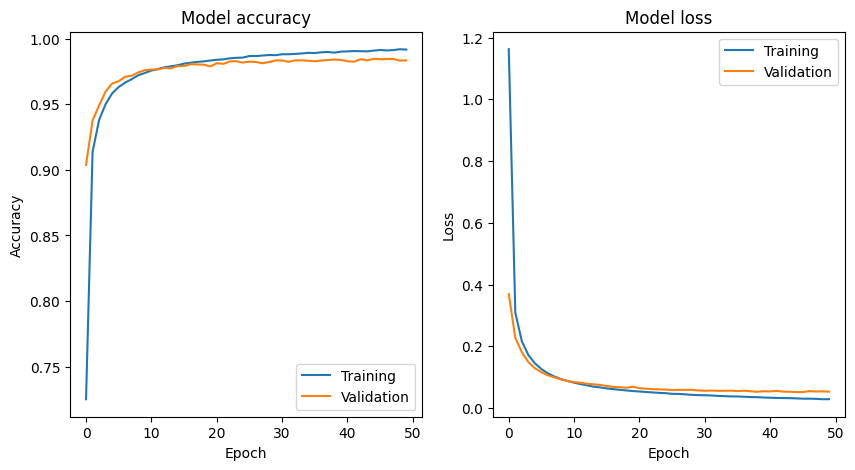

```
The model has a training accuracy of 99.17%
The model has a validation accuracy of 98.34%
```

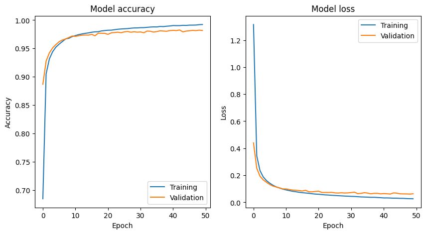

```
The model has a training accuracy of 99.23%
The model has a validation accuracy of 98.18%
```

```python
plot_performance(history_2Conv)
plot_performance(history_3Conv)
```

# Custom Test Set

## Import the Test Set + Preprocessing

In this section, I will import my own handwritten digits as a custome dataset. The dataset has 25 instances of each digit, meaning 250 samples in total. The samples of each digit is contained within their respective folders with their corresponding name, which also acts as the label since the folder name is later extracted as the custom label.

The images were previously cropped. In this code, each image is resized to have size 28x28. Since the brushstroke of the handwritten digits were too thin compared to that of the MNIST dataset, I applied an errosion filter on them to widen the brushstroke. I also applied a Gaussian blur mask on the inputs to make the edges less sharp

The path for the import is different on Google Colab and on a PC. For this assignment, I ran model training on my own PC so that path was chosen. Each of the image was resized to 28x28 pixels to match the input shape of the MNIST dataset

```python
import os
import numpy as np
from PIL import Image
import cv2
from tensorflow.keras.utils import to_categorical

output_classes = 10

# Load custom images from Google Drive
custom_images_raw = []
custom_labels_raw = []

# Use the following when working on Google Colab
# base_folder_path = '/content/drive/MyDrive/TME6015/Assignment 1/Custom_Dataset'

# Use the following path when working on PC
# base_folder_path = '\\Minh Nguyen\\TME_6015\\Assignment_1\\Custom Set'
base_folder_path = 'D:\\Minh Nguyen\\TME_6015\\Assignment_1\\Custom Set'

for folder_name in os.listdir(base_folder_path):
    folder_path = os.path.join(base_folder_path, folder_name)
    print(folder_path)
    if os.path.isdir(folder_path):
        for filename in os.listdir(folder_path):
            if filename.endswith('.png') or filename.endswith('.PNG') or filename.endswith('.JPG'):
                img_path = os.path.join(folder_path, filename)
                img = Image.open(img_path).convert('L')  # Convert image to grayscale
                img = img.resize((28, 28))  # Resize image to match MNIST data

                # Thresholding
                threshold = 100
                img = img.point(lambda p: p > threshold and 255)

                img_array = np.array(img)

                # Convert to uint8 for OpenCV
                img_array = np.uint8(img_array)

                # Dilation to thicken brush strokes
                kernel = np.ones((2, 2), np.uint8)  # Create a 5x5 kernel for dilation
                img_eroded = cv2.erode(img_array, kernel, iterations=1)

                # Add some blur on the image to resemble the MNIST training data
                img_blurred = cv2.GaussianBlur(img_eroded, (3,3), 0.65)

                # Choose which img is used to add in the testing set (eroded or erroed+blurred)
                custom_image_raw = img_blurred

                custom_images_raw.append(custom_image_raw)
                custom_labels_raw.append(int(folder_name))  # Use folder name as label

# Convert the list of custom images and labels to numpy arrays
custom_images_raw = np.array(custom_images_raw)
custom_labels_raw = np.array(custom_labels_raw)

# Preprocess the custom images
custom_images = custom_images_raw / 255.0

# One hot encode the labels
custom_labels = to_categorical(custom_labels_raw, num_classes=output_classes)

print(f"Dimension of the custom_images set: {custom_images.shape}\n"
      f"Dimension of the y_train set: {custom_labels.shape}")
```

```
D:\Minh Nguyen\TME_6015\Assignment_1\Custom Set\0
D:\Minh Nguyen\TME_6015\Assignment_1\Custom Set\1
D:\Minh Nguyen\TME_6015\Assignment_1\Custom Set\2
D:\Minh Nguyen\TME_6015\Assignment_1\Custom Set\3
D:\Minh Nguyen\TME_6015\Assignment_1\Custom Set\4
D:\Minh Nguyen\TME_6015\Assignment_1\Custom Set\5
D:\Minh Nguyen\TME_6015\Assignment_1\Custom Set\6
D:\Minh Nguyen\TME_6015\Assignment_1\Custom Set\7
D:\Minh Nguyen\TME_6015\Assignment_1\Custom Set\8
D:\Minh Nguyen\TME_6015\Assignment_1\Custom Set\9
Dimension of the custom_images set: (250, 28, 28)
Dimension of the y_train set: (250, 10)
```

```python
print(custom_labels)
```

```
[[1. 0. 0. ... 0. 0. 0.]
 [1. 0. 0. ... 0. 0. 0.]
 [1. 0. 0. ... 0. 0. 0.]
 ...
 [0. 0. 0. ... 0. 0. 1.]
 [0. 0. 0. ... 0. 0. 1.]
 [0. 0. 0. ... 0. 0. 1.]]
```

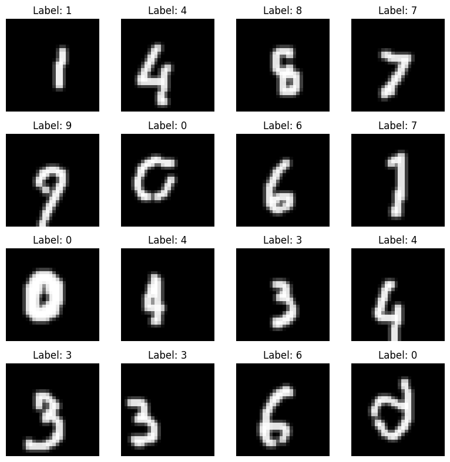

```python
custom_images.shape

num_samples = 16; num_rows = 4; num_cols = np.int8(num_samples/num_rows)
rand = random.randint(250,size = (num_samples))
x_samples = custom_images[rand,:,:]
y_samples = np.argmax(custom_labels[rand],axis=1)

fig, axes = plt.subplots(num_rows,num_cols,figsize=(num_rows*2,num_cols*2))

for i in range(num_rows):
  for j in range(num_cols):
    ax = axes[i,j]
    ax.imshow(x_samples[i*num_cols+j,:,:], cmap=matplotlib.cm.Greys)
    ax.axis("off")
    ax.set_title(f"Label: {y_samples[i*num_cols+j]}")

plt.tight_layout()
plt.subplots_adjust(top=0.95)  # Adjust top to make room for title
plt.show()
```

```python
# Add the custom images and labels to the original MNIST dataset
x_train = np.concatenate((x_train, custom_images), axis=0)
y_train = np.concatenate((y_train, custom_labels), axis=0)

keras.backend.clear_session(
    free_memory=True
)

batch_size = 32
lr = 0.0001
epochs = 20

optimizer = keras.optimizers.Adam(
    learning_rate = lr
)

model_2Conv = keras.Sequential([
    layers.Conv2D(32, kernel_size=(3, 3), activation="relu", input_shape = input_shape),
    layers.MaxPooling2D(pool_size=(2, 2)),
    layers.Conv2D(64, kernel_size=(3, 3), activation="relu"),
    layers.MaxPooling2D(pool_size=(2, 2)),
    # layers.Conv2D(32, kernel_size=(3, 3), activation="relu"),
    # layers.MaxPooling2D(pool_size=(2, 2)),
    layers.Dropout(0.2),
    layers.Flatten(),
    layers.Dense(output_classes, activation="softmax"),
])

model_2Conv.summary()

model_2Conv.compile(loss="categorical_crossentropy",
              optimizer=optimizer,
              metrics=["accuracy"])

history_2Conv = model_2Conv.fit(x_train, y_train, batch_size=batch_size, epochs=epochs, validation_split=0.2)
```

```
d:\Minh Nguyen\TME_6015\.venv\Lib\site-packages\keras\src\layers\convolutional\base_conv.py:107: UserWarning: Do not pass an `input_shape`/`input_dim` argument to a layer. When using Sequential models, prefer using an `Input(shape)` object as the first layer in the model instead.
  super().__init__(activity_regularizer=activity_regularizer, **kwargs)
```

```
Model: "sequential"
```

```
┏━━━━━━━━━━━━━━━━━━━━━━━━━━━━━━━━━┳━━━━━━━━━━━━━━━━━━━━━━━━┳━━━━━━━━━━━━━━━┓
┃ Layer (type)                    ┃ Output Shape           ┃       Param # ┃
┡━━━━━━━━━━━━━━━━━━━━━━━━━━━━━━━━━╇━━━━━━━━━━━━━━━━━━━━━━━━╇━━━━━━━━━━━━━━━┩
│ conv2d (Conv2D)                 │ (None, 26, 26, 32)     │           320 │
├─────────────────────────────────┼────────────────────────┼───────────────┤
│ max_pooling2d (MaxPooling2D)    │ (None, 13, 13, 32)     │             0 │
├─────────────────────────────────┼────────────────────────┼───────────────┤
│ conv2d_1 (Conv2D)               │ (None, 11, 11, 64)     │        18,496 │
├─────────────────────────────────┼────────────────────────┼───────────────┤
│ max_pooling2d_1 (MaxPooling2D)  │ (None, 5, 5, 64)       │             0 │
├─────────────────────────────────┼────────────────────────┼───────────────┤
│ dropout (Dropout)               │ (None, 5, 5, 64)       │             0 │
├─────────────────────────────────┼────────────────────────┼───────────────┤
│ flatten (Flatten)               │ (None, 1600)           │             0 │
├─────────────────────────────────┼────────────────────────┼───────────────┤
│ dense (Dense)                   │ (None, 10)             │        16,010 │
└─────────────────────────────────┴────────────────────────┴───────────────┘
```

```
 Total params: 34,826 (136.04 KB)
```

```
 Trainable params: 34,826 (136.04 KB)
```

```
 Non-trainable params: 0 (0.00 B)
```

```
1507/1507 ━━━━━━━━━━━━━━━━━━━━ 6s 4ms/step - accuracy: 0.6688 - loss: 1.1756 - val_accuracy: 0.9313 - val_loss: 0.2398
1507/1507 ━━━━━━━━━━━━━━━━━━━━ 5s 4ms/step - accuracy: 0.9371 - loss: 0.2130 - val_accuracy: 0.9476 - val_loss: 0.1785
1507/1507 ━━━━━━━━━━━━━━━━━━━━ 5s 3ms/step - accuracy: 0.9559 - loss: 0.1469 - val_accuracy: 0.9568 - val_loss: 0.1494
1507/1507 ━━━━━━━━━━━━━━━━━━━━ 6s 4ms/step - accuracy: 0.9636 - loss: 0.1222 - val_accuracy: 0.9600 - val_loss: 0.1338
1507/1507 ━━━━━━━━━━━━━━━━━━━━ 6s 4ms/step - accuracy: 0.9686 - loss: 0.1038 - val_accuracy: 0.9635 - val_loss: 0.1240
1507/1507 ━━━━━━━━━━━━━━━━━━━━ 5s 4ms/step - accuracy: 0.9727 - loss: 0.0885 - val_accuracy: 0.9663 - val_loss: 0.1166
1507/1507 ━━━━━━━━━━━━━━━━━━━━ 6s 4ms/step - accuracy: 0.9758 - loss: 0.0815 - val_accuracy: 0.9671 - val_loss: 0.1106
1507/1507 ━━━━━━━━━━━━━━━━━━━━ 6s 4ms/step - accuracy: 0.9770 - loss: 0.0767 - val_accuracy: 0.9690 - val_loss: 0.1073
1507/1507 ━━━━━━━━━━━━━━━━━━━━ 6s 4ms/step - accuracy: 0.9785 - loss: 0.0715 - val_accuracy: 0.9676 - val_loss: 0.1077
1507/1507 ━━━━━━━━━━━━━━━━━━━━ 5s 4ms/step - accuracy: 0.9810 - loss: 0.0637 - val_accuracy: 0.9699 - val_loss: 0.1041
1507/1507 ━━━━━━━━━━━━━━━━━━━━ 6s 4ms/step - accuracy: 0.9819 - loss: 0.0596 - val_accuracy: 0.9704 - val_loss: 0.1000
1507/1507 ━━━━━━━━━━━━━━━━━━━━ 5s 3ms/step - accuracy: 0.9843 - loss: 0.0529 - val_accuracy: 0.9716 - val_loss: 0.0978
1507/1507 ━━━━━━━━━━━━━━━━━━━━ 6s 4ms/step - accuracy: 0.9843 - loss: 0.0540 - val_accuracy: 0.9715 - val_loss: 0.1006
1507/1507 ━━━━━━━━━━━━━━━━━━━━ 6s 4ms/step - accuracy: 0.9852 - loss: 0.0515 - val_accuracy: 0.9720 - val_loss: 0.0986
1507/1507 ━━━━━━━━━━━━━━━━━━━━ 6s 4ms/step - accuracy: 0.9870 - loss: 0.0436 - val_accuracy: 0.9722 - val_loss: 0.0980
1507/1507 ━━━━━━━━━━━━━━━━━━━━ 6s 4ms/step - accuracy: 0.9872 - loss: 0.0437 - val_accuracy: 0.9722 - val_loss: 0.0988
1507/1507 ━━━━━━━━━━━━━━━━━━━━ 6s 4ms/step - accuracy: 0.9873 - loss: 0.0419 - val_accuracy: 0.9716 - val_loss: 0.0992
1507/1507 ━━━━━━━━━━━━━━━━━━━━ 6s 4ms/step - accuracy: 0.9878 - loss: 0.0412 - val_accuracy: 0.9731 - val_loss: 0.0987
1507/1507 ━━━━━━━━━━━━━━━━━━━━ 6s 4ms/step - accuracy: 0.9868 - loss: 0.0423 - val_accuracy: 0.9729 - val_loss: 0.0996
1507/1507 ━━━━━━━━━━━━━━━━━━━━ 6s 4ms/step - accuracy: 0.9875 - loss: 0.0388 - val_accuracy: 0.9734 - val_loss: 0.0997
```

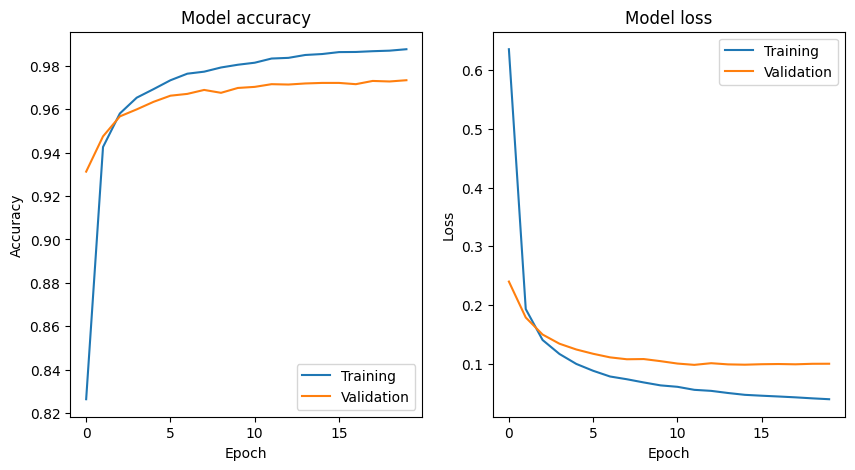

```
The model has a training accuracy of 98.77%
The model has a validation accuracy of 97.34%
```

```python
plot_performance(history_2Conv)
```

## Evaluate the new model performance

```python
test_model = model_2Conv

custom_loss, custom_accuracy = test_model.evaluate(custom_images, custom_labels, verbose=1)
print(f"Custom Data - Loss: {custom_loss}, Accuracy: {custom_accuracy}")
```

```
8/8 ━━━━━━━━━━━━━━━━━━━━ 0s 2ms/step - accuracy: 0.3396 - loss: 2.7739
8/8 ━━━━━━━━━━━━━━━━━━━━ 0s 2ms/step - accuracy: 0.3396 - loss: 2.7739
Custom Data - Loss: 2.689124584197998, Accuracy: 0.30399999022483826
```

In the following code block, I am using the trained model to make predictions on the custom dataset. Afterward, I will visualize the model prediction and compare it with the label imported from the custom set

```
8/8 ━━━━━━━━━━━━━━━━━━━━ 0s 7ms/step
[5 5 1 2 1 5 2 1 5 1 2 5 7 1 5 2 2 2 1 7 2 2 2 5 2 2 2 2 2 2 1 2 5 1 5 2 1
 2 5 1 2 2 2 2 2 3 5 9 2 5 7 2 2 2 2 2 5 5 1 2 2 2 7 2 2 2 2 5 2 1 5 7 5 2
 1 2 5 5 2 2 5 5 2 7 2 2 2 2 2 2 2 5 5 5 2 5 2 1 3 1]
```

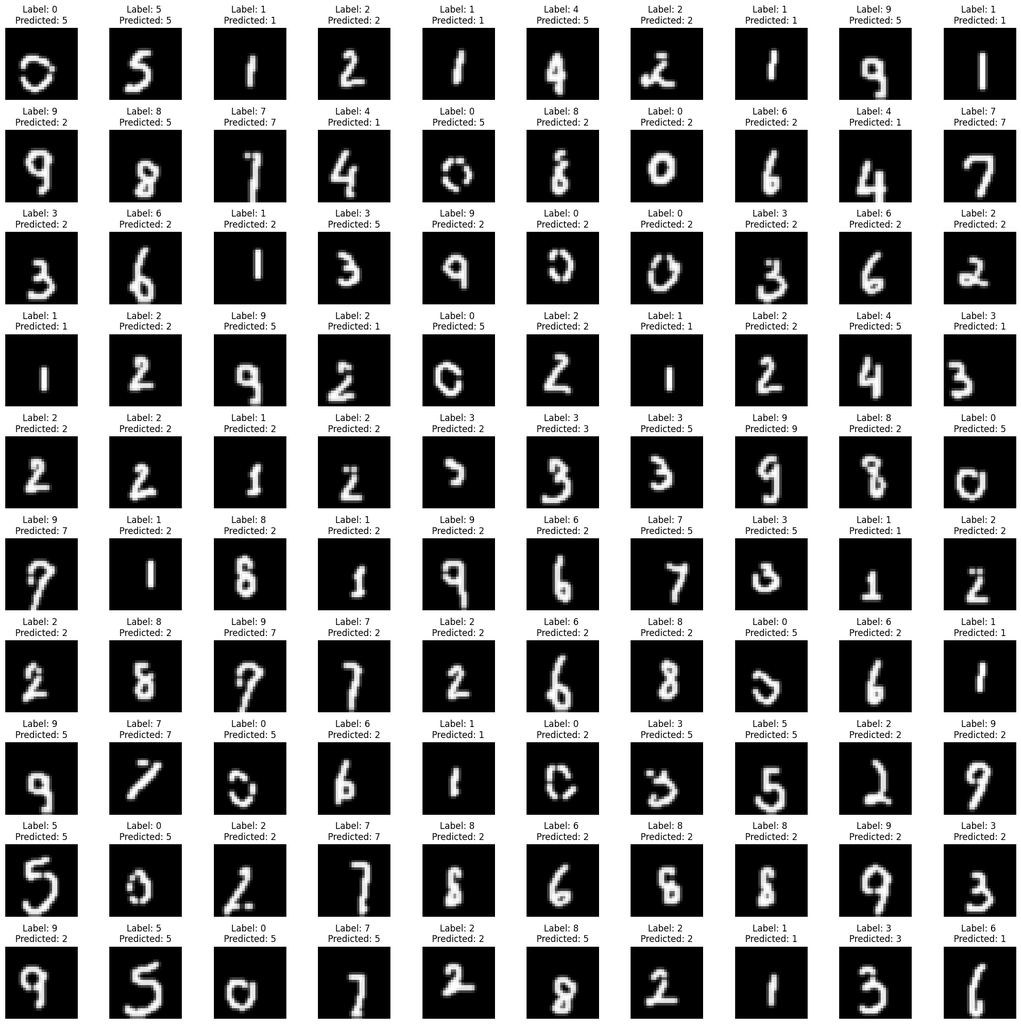

```python
custom_images.shape

num_samples = 100; num_rows = np.int8(np.sqrt(num_samples)); num_cols = np.int8(num_samples/num_rows)
rand = random.randint(250,size = (num_samples))
x_samples = custom_images[rand,:,:]
y_samples = np.argmax(custom_labels[rand],axis=1)

predictions = test_model.predict(custom_images)
y_predicted = np.argmax(predictions[rand],axis=1)
print(y_predicted)

fig, axes = plt.subplots(num_rows,num_cols,figsize=(num_rows*2,num_cols*2))

for i in range(num_rows):
  for j in range(num_cols):
    ax = axes[i,j]
    ax.imshow(x_samples[i*num_cols+j,:,:], cmap=matplotlib.cm.Greys)
    ax.axis("off")
    ax.set_title(f"Label: {y_samples[i*num_cols+j]} \n"
                 f"Predicted: {y_predicted[i*num_cols+j]}")

plt.tight_layout()
plt.subplots_adjust(top=0.95)  # Adjust top to make room for title
plt.show()
```

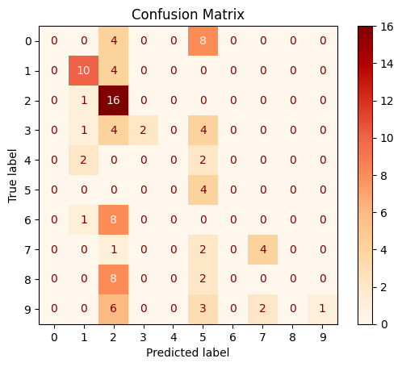

```python
from sklearn.metrics import confusion_matrix, ConfusionMatrixDisplay

cm = confusion_matrix(y_samples, y_predicted)
disp = ConfusionMatrixDisplay(confusion_matrix=cm)
disp.plot(cmap=plt.cm.OrRd)  # You can change the color map as desired
plt.title("Confusion Matrix")
plt.show()
```